# The Lighting Jolt Scene

We create a lightning jolt each time the lightning flashes. The jolt’s purpose is to calculate its `Line2D` points, look pretty, then destroy itself.

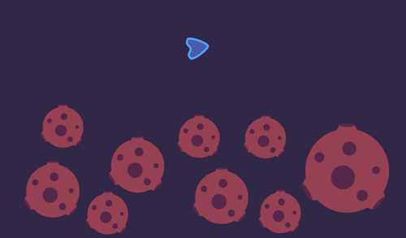

Open up the lighting jolt scene, and let’s get to work.

## Updating Line2D settings

Let’s take a look at the *LightningJolt* node’s settings. The further away from the source, the less energy lightning has. Is this true in real life? I have no idea! But thinning the line as it gets further away makes the shape look more exciting and focuses our attention on the point of impact.

We start by setting the width to `6` pixels and creating a new width curve. You can make the default color property whatever you like. When I think of lightning or electricity, I think of a light blue.

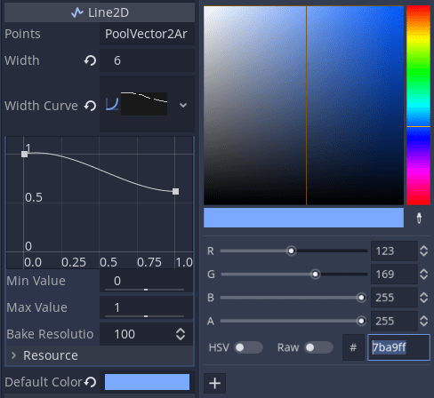

The capping setting further dictate the shape of the Line2D.

Set the *Capping -> Joint Mode* to *Sharp* to get jagged corners at the end of segments. We want round caps at the start and the end of the curve though. To do so, set both *Capping -> Begin Cap Mode* and *Capping -> End Cap Mode* to *Round*. They won’t be very noticeable, but it looks better than having rectangular start and end.

Set the *Visibility -> Z Index* to `-1` so the jolt appears behind visuals with a higher value.

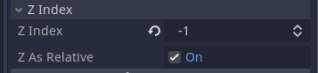

If an object has a *Modulate* (or color) that exceeds the base values, it’ll glow with as long as there’s a *WorldEnvironment* node present in the same scene. To make our jolt glow, toggle *Raw* and set the values above `1.0`. I used `1.3` in the red, green, and blue channels.

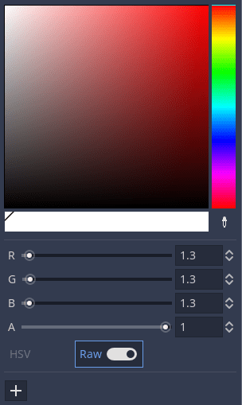

## Creating particles

The Sparks node is our `Particles2D`. Their position will be where the LightningJolt ends. Let’s take a look at the first set of settings.

We’ll emit the particles using the `AnimationPlayer` so, for now, we’ll set *Emitting* to `false`.

Let’s use a small *Amount* to keep the sparks subtle. I set it to `4`. With multiple flashes, there will already be plenty of particles flying around.

We don’t want the particles to repeat, so we set *Time -> One Shot* to `true`. The explosiveness controls the period in which the particles are emitted. The closer to `1`, the closer in time the particles appear. We set this to `1` so all sparks fly together when the node starts emitting. Also, set *Time -> Randomness* to `1` to randomize the sparks’ lifetime.

Here are my settings so far.

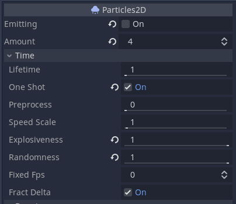

Add a new *ParticlesMaterial* in *Process Material -> Material* and expand it. This is where we design the particles’ motion. First, ensure that *Flags -> Disable Z* is checked. We’re working in 2D and don’t want the particles using this third dimension.

Set the *Direction -> Direction* to `(0, 0, 0)` and *Direction -> Spread* to `180`. This will allow our particles to shoot in any direction.

Set the *Gravity -> Gravity* to `(0, 0, 0)` too because in this example, the sparks are in space and we don’t want our sparks to fall as if we were on Earth.

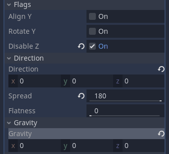

Let’s talk velocity! You can play around with these values, but I want the particles to have a decent speed and spin. I set the *Velocity* to `128` with a randomness of `0.5`. I want some variance in the velocity, but I still want them to have a defined shape when they’re emitted.

I set the angular velocity to `128` too, with `1` for the randomness.

Damping is one of my favorite settings. It adds friction to the particles’ movement. You’ll notice the higher the damping, the quicker the particles slow down. Play around with the value until the effect feels satisfying to you.

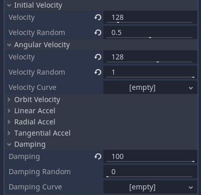

Add a scale curve so the particles appear to dissipate. In the scale property, create a curve and edit it so it tends towards `0`.

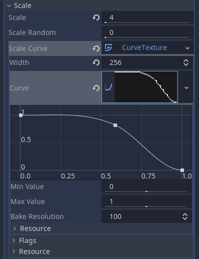

The final property in the particles material is the color. I set it to the same as the Line2D color above.

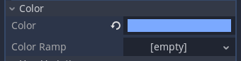

Let’s add a subtle glow to the sparks by pushing the RAW values of the color above `1.0`, as we did above.

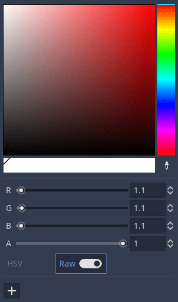

If you set the particles to emit, you should see this result. I’ve also set the particles one_shot to false to loop the effect. Be sure to change these settings back once you’ve had a look at the result. We’ll be using the *AnimationPlayer* to control when the particles appear.

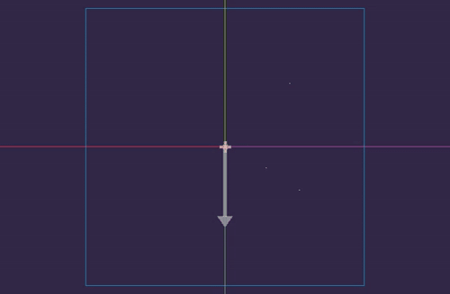

## Animating the jolt

Let’s use an animation to sequence our sparks’ emission and destroy the jolt instance after fading it out. Select the *AnimationPlayer*, create a new animation called “destroy”, and toggle *Autoplay on Load*.

Add a track to start `emitting` the *Sparks* as soon as the animation plays.

Also, have the `self_modulate` fade out after a delay. To destroy the jolt, create a new function call track by clicking *Add Track*. Create a keyframe on that track at the two-second mark and call `queue_free()`. Two seconds is enough time for our particles to finish their animation.

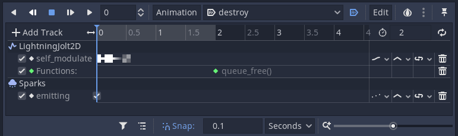

[The AnimationPlayer documentation](https://docs.godotengine.org/en/stable/tutorials/animation/introduction_2d.html) offers more information as to how to set these tracks up if you need it.

Next, we’ll dive into the lightning beam script and have it create multiple jolt effects.